# Parte 4

Erick Emiliano Aduna Camilo

19/3/2022

##Red de Cogustos

Cargamos el paquete de igraph puesto que será necesario.

```r
library(igraph)
```

Ahora con los datos de la red de cogustos debemos primero prepararla

Una vez este lista en base al valor que se definio como coexpresión o en este caso a co gustoss, gráficamos y se nos indica que minimo deben existir tres outlayers, el valor que se uso como punto umbran fue el 0.75, por lo que valores menores a estos en base a la matriz de correlaciones implica que no hay cogusto, hay valores dentro de la matriz que no alcanzan este valor, por lo que no conectan con ningun otro nodo.

La gráfica se ve así:

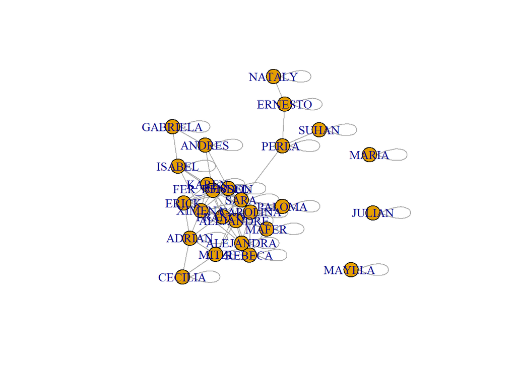

```r
plot(red_series)
```

Como se observa para la red dicotomica es decir de ceros y unos, encontramos 3 outlayers

**Obtener la distribución de conectividades de la red dicotomica.**

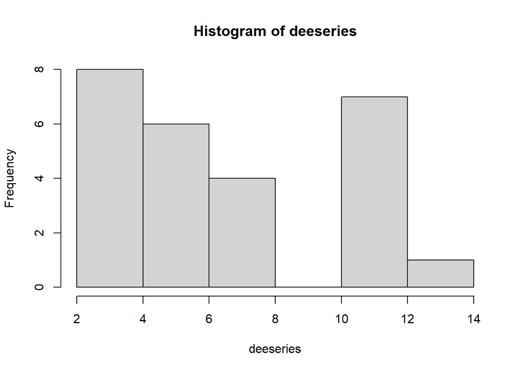

```r
deeseries <- degree(red_series)


hist(deeseries)
```

**Obtener los tres nodos más conectados de la red dicotomica**

```r
 head(sort(deeseries, decreasing = T),3)
```

```
## ALEJANDRE    CAROLINA    FRANCO
##         13         12         12
```

```r
#Usando el deegre

head(sort(deeseries, decreasing = T),3)
```

```
## ALEJANDRE    CAROLINA    FRANCO
##         13         12         12
```

```r
#Usando la exentricidad

head(sort(eccentricity(red_series), decreasing = F),3)
```

```
##  JULIAN MAYELA    MARIA
##       0       0       0
```

```r
#Usando el closeness
head(sort(closeness(red_series),decreasing = T),3)
```

```
##        SARA  ALEJANDRE   FER_RENDON
## 0.008695652 0.008620690 0.008547009
```

**Clusters obtenidos con al menos tres métodos**

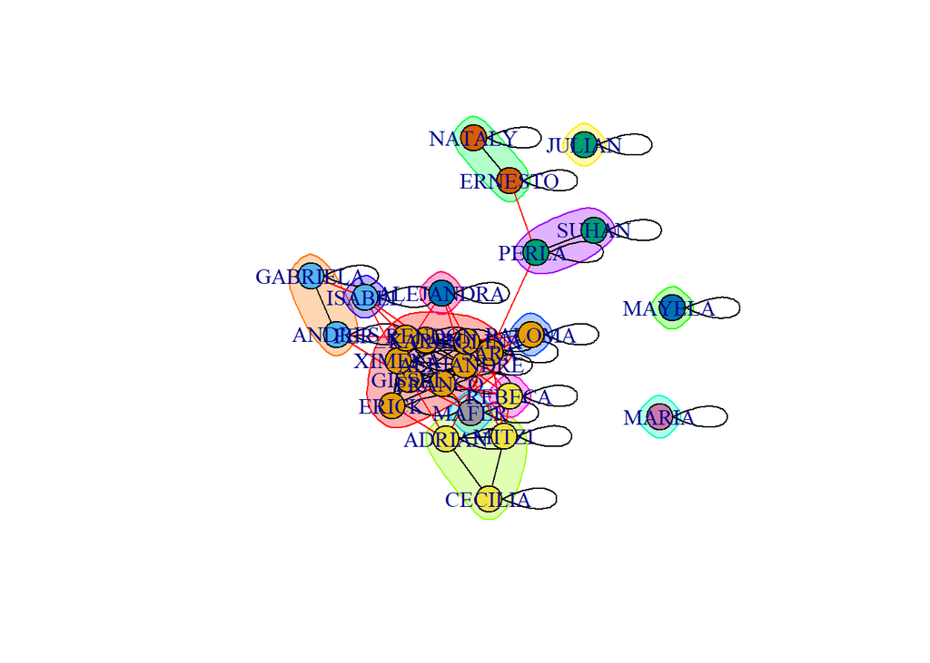

```r
#Para la red dicotomica

#Con cluster edge betweenness
unoc <- cluster_edge_betweenness(red_series)

plot(unoc, red_series)
```

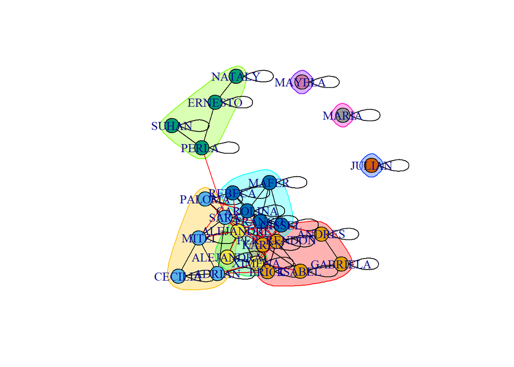

```r
#Con fast greedy
dosc <- cluster_fast_greedy(red_series)

plot(dosc, red_series)
```

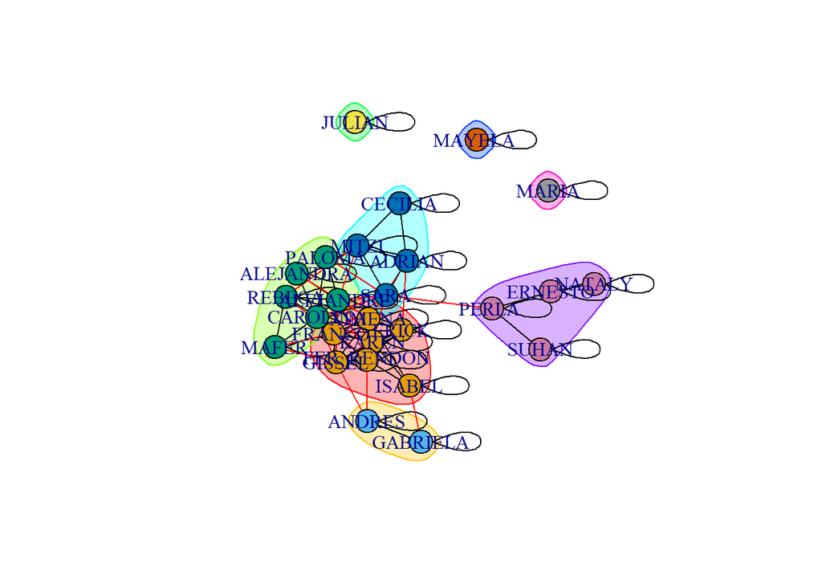

```r
# Con Optimal

tresc <- cluster_optimal(red_series)


plot(tresc, red_series)
```

**Discusión del tipo de Red**

Ambas redes son **no dirigidas** debido a que no importa la dirección de la conexión lo que importa es que superen el valor umbral inicial, si lo superan los nodos estan conectados no hay in o out, y en el caso de la red pesada solo implica en este caso en particular que tan afines seían dos personas en cuanto a las series que ven, pero no importa la dirección de la nonexión.